# Graded Novelty Encoding Task - lab study analysis

# Study phase:

During the study phase, the participants see familiar and novel items.

The participants produced a mean (±sd) recognition rate of 0.6884211 ± 0.1531388 for familiar pictures.

The participants produced a mean (±sd) corrected recognition rate of 0.4231579 ± 0.2178284 for familiar pictures.

Uncorrected: The sample performed above chance levels, as a one sample t-test showed (t(37)=7.5846574, p = 4.78399^{-9}, Cohen’s d = 1.2303939, 95% CI:0.513504 - 1.9472838).

Corrected: The sample performed above chance levels, as a one sample t-test showed (t(37)=11.9751157, p = 2.7109584^{-14}, Cohen’s d = 1.9426203, 95% CI:1.1451184 - 2.7401222).

We use an ANOVA to see if there is a difference in correct rejection for the different novels.

```
## Anova Table (Type 3 tests)
##
## Response: N
##   Effect          df  MSE       F  ges p.value
## 1   type 2.55, 45.98 1.74 5.79 ** .079    .003
## ---
## Signif. codes:  0 '***' 0.001 '**' 0.01 '*' 0.05 '+' 0.1 ' ' 1
##
## Sphericity correction method: GG
```

```
##  contrast             estimate    SE df t.ratio p.value
##  diffarr - sarr          0.947 0.310 18   3.052  0.0473
##  diffarr - sarrcol       0.632 0.308 18   2.051  0.2827
##  diffarr - sarrsha       1.579 0.392 18   4.025  0.0062
##  diffarr - sarrshacol    1.053 0.259 18   4.064  0.0057
##  sarr - sarrcol         -0.316 0.390 18  -0.809  0.9244
##  sarr - sarrsha          0.632 0.267 18   2.364  0.1708
##  sarr - sarrshacol       0.105 0.295 18   0.357  0.9962
##  sarrcol - sarrsha       0.947 0.487 18   1.947  0.3295
##  sarrcol - sarrshacol    0.421 0.309 18   1.363  0.6574
##  sarrsha - sarrshacol   -0.526 0.337 18  -1.564  0.5373
##
## P value adjustment: tukey method for comparing a family of 5 estimates
```

```
##  contrast  estimate    SE df t.ratio p.value
##  linear      -2.737 0.634 18  -4.313  0.0004
##  quadratic    1.684 0.738 18   2.283  0.0348
##  cubic        0.211 0.538 18   0.391  0.7004
##  quartic      5.263 2.965 18   1.775  0.0927
```

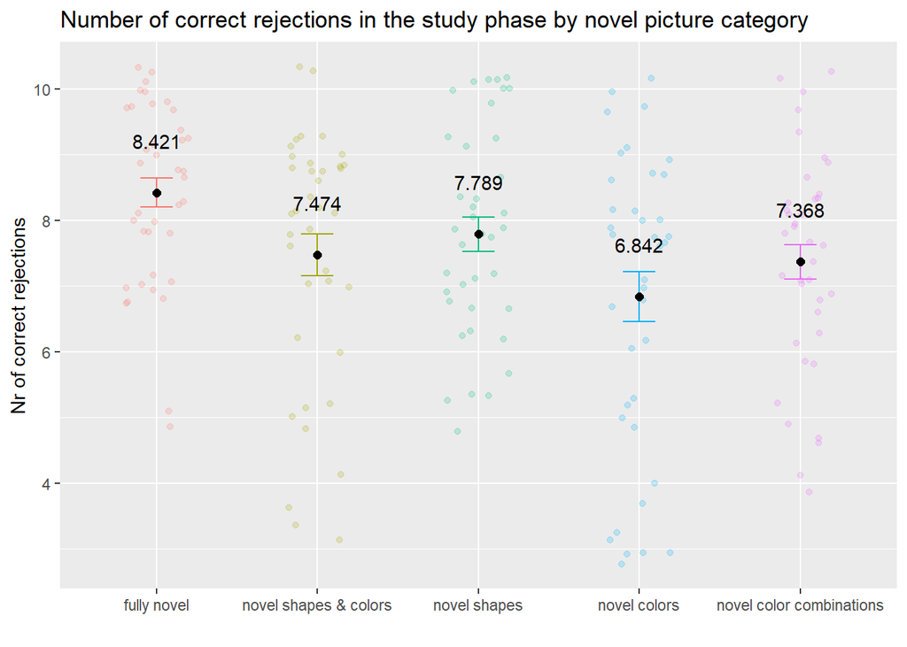

# Test phase:

This phase tests the learning that has occurred during the study phase. If the participants learned the novels in the study phase, their responses should differ for the stimuli that they have already seen during the study phase (familiars) and those that they see for the first time during the test phase (novels). We also let the participants to choose “maybe” by pressing the down arrow, but asked them not to overuse this response (maybe resp <= 50). We added these responses as correct responses to both stimulus categories.

Maybe responses (MEAN ± SD): 9.7894737 ± 6.0971664.

```
## [1] "A t-test to compare the number of old responses btwn old and new stim"
```

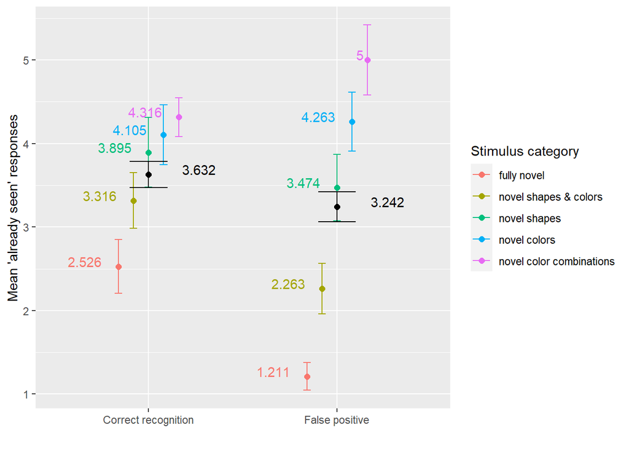

Results of the paired t-test: (t(189)=2.9238502, p = 0.0038799, Cohen’s d = 0.1656133, 95% CI:0.053479 - 0.2777477).

Shapiro-Wilk is significant (p = 4.8017851^{-5}).

We used a Wilcoxon sgined-rank test. Z = -2.3653152, p = 0.0090074

## ANOVA - Corrected Recog

```
## Anova Table (Type 3 tests)
##
## Response: CorrRecog
##     Effect          df  MSE       F  ges p.value
## 1 neworder 3.22, 57.97 3.50 4.64 ** .164    .005
## ---
## Signif. codes:  0 '***' 0.001 '**' 0.01 '*' 0.05 '+' 0.1 ' ' 1
##
## Sphericity correction method: GG
```

```
##  contrast estimate    SE df t.ratio p.value
##  A - B       0.263 0.529 18   0.498  0.9866
##  A - C       1.474 0.385 18   3.826  0.0095
##  A - D       0.895 0.540 18   1.656  0.4832
##  A - E       2.000 0.478 18   4.188  0.0044
##  B - C       1.211 0.624 18   1.940  0.3330
##  B - D       0.632 0.568 18   1.112  0.7984
##  B - E       1.737 0.571 18   3.039  0.0485
##  C - D      -0.579 0.564 18  -1.027  0.8396
##  C - E       0.526 0.461 18   1.141  0.7830
##  D - E       1.105 0.671 18   1.648  0.4879
##
## P value adjustment: tukey method for comparing a family of 5 estimates
```

```
##  contrast  estimate   SE df t.ratio p.value
##  linear      -4.632 1.01 18  -4.602  0.0002
##  quadratic    0.105 1.22 18   0.086  0.9322
##  cubic       -0.737 1.32 18  -0.558  0.5835
##  quartic     -6.211 3.85 18  -1.614  0.1238
```

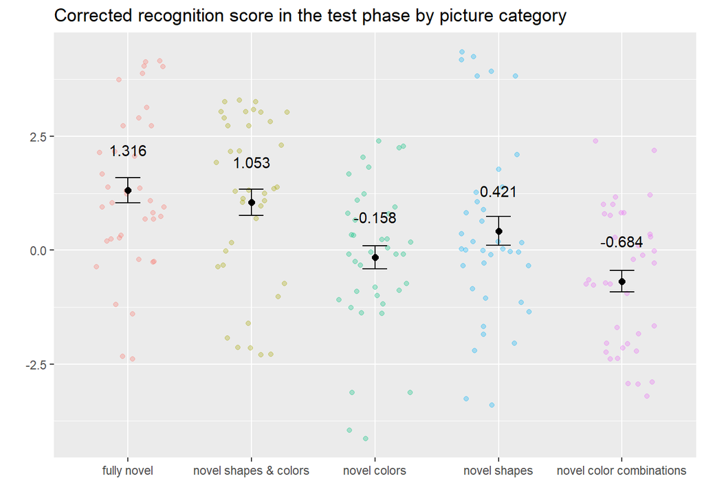

ANOVA (factor: TYPE (5 lvls)): (F[3.2208046,57.9744834] = 4.636788, p = 0.0047208, n2G = 0.1640785).

# Mixed models

The metrics

-DTF - Difference To corresponding Familiar picture All pictures are compared to a familiar. The number of differences between the three vectors of the pictures yields a difference score.

-DTAF - mean Difference To All Familiars We calculate the difference from all prototypes and take the mean for each picture in the set.

-DTN - mean Difference To All other Novels in the same category We calculate the differences between each pair of pictures and then take the mean of these differences (19 comparisons per stim).

## Study phase

With these models i tried to assess which difference index explains familiar v novel distinction in study phase the best. As far as i understand, the model with the smallest AIC fits best to our data, which means that the mean difference from the corresponding familiar worked best here. The models all show, that the more different pictures are categorized with the highest efficacy.

```
## Generalized linear mixed model fit by maximum likelihood (Laplace
##   Approximation) [glmerMod]
##  Family: binomial  ( logit )
## Formula: st_corr ~ DTF + (1 | workerId)
##    Data: stlmm
##
##      AIC      BIC   logLik deviance df.resid
##   1596.3   1612.0   -795.1   1590.3     1422
##
## Scaled residuals:
##     Min      1Q  Median      3Q     Max
## -2.9543 -1.0903  0.4863  0.6362  1.0000
##
## Random effects:
##  Groups   Name        Variance Std.Dev.
##  workerId (Intercept) 0.2598   0.5097
## Number of obs: 1425, groups:  workerId, 19
##
## Fixed effects:
##             Estimate Std. Error z value Pr(>|z|)
## (Intercept)  0.83704    0.14181   5.902 3.58e-09 ***
## DTF          0.05766    0.01302   4.428 9.52e-06 ***
## ---
## Signif. codes:  0 '***' 0.001 '**' 0.01 '*' 0.05 '.' 0.1 ' ' 1
##
## Correlation of Fixed Effects:
##     (Intr)
## DTF -0.344
```

[output not shown]

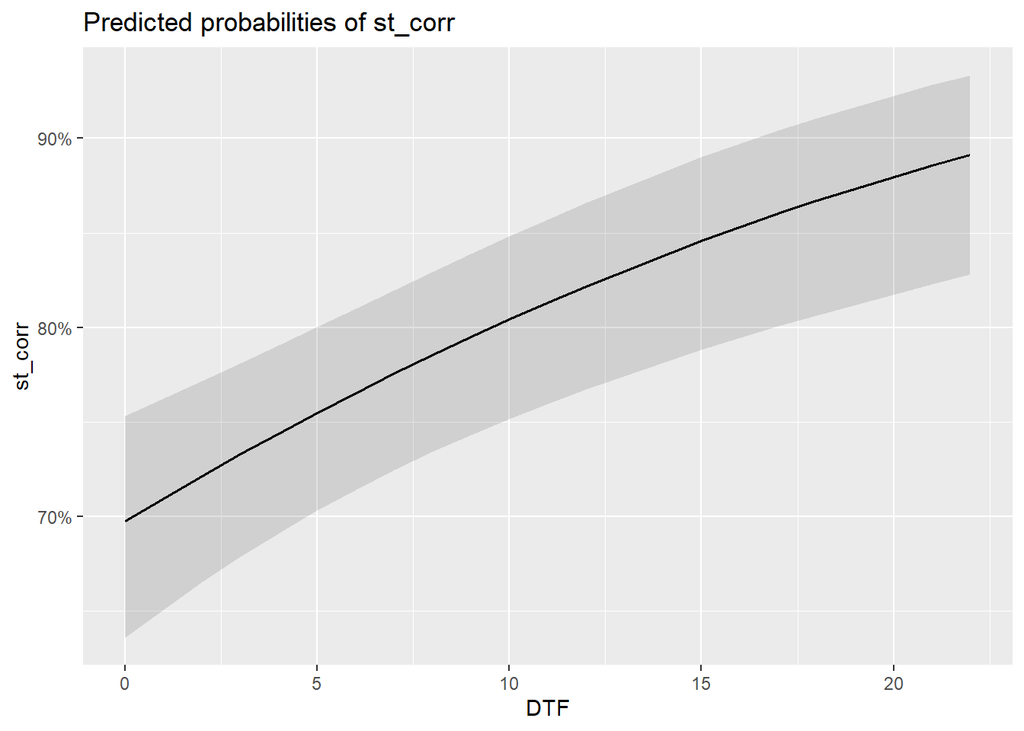

```
## Generalized linear mixed model fit by maximum likelihood (Laplace
##   Approximation) [glmerMod]
##  Family: binomial  ( logit )
## Formula: st_corr ~ DTAF + (1 | workerId)
##    Data: stlmm
##
##      AIC      BIC   logLik deviance df.resid
##   1602.3   1618.1   -798.2   1596.3     1422
##
## Scaled residuals:
##     Min      1Q  Median      3Q     Max
## -2.7136 -1.1393  0.4873  0.6203  1.0325
##
## Random effects:
##  Groups   Name        Variance Std.Dev.
##  workerId (Intercept) 0.2579   0.5078
## Number of obs: 1425, groups:  workerId, 19
##
## Fixed effects:
##             Estimate Std. Error z value Pr(>|z|)
## (Intercept) 0.769269   0.151888   5.065 4.09e-07 ***
## DTAF        0.037334   0.009401   3.971 7.15e-05 ***
## ---
## Signif. codes:  0 '***' 0.001 '**' 0.01 '*' 0.05 '.' 0.1 ' ' 1
##
## Correlation of Fixed Effects:
##      (Intr)
## DTAF -0.486
```

[output not shown]

```
## Data were 'prettified'. Consider using `terms="DTAF [all]"` to get smooth plots.
```

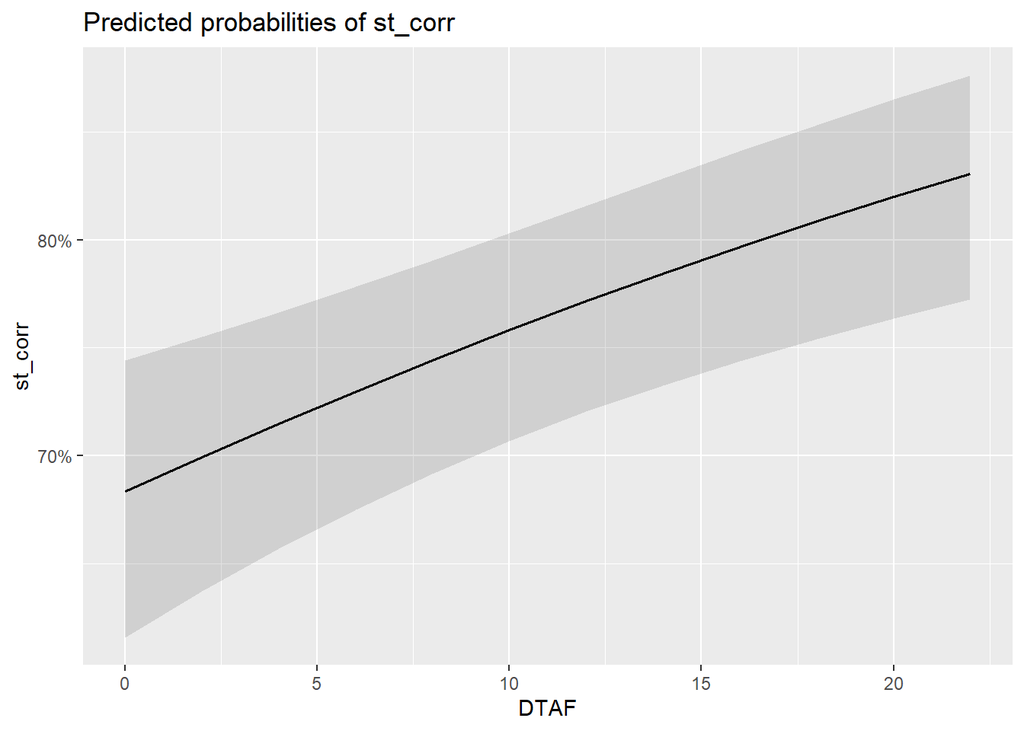

```
## Generalized linear mixed model fit by maximum likelihood (Laplace
##   Approximation) [glmerMod]
##  Family: binomial  ( logit )
## Formula: st_corr ~ DTAN + (1 | workerId)
##    Data: stlmm
##
##      AIC      BIC   logLik deviance df.resid
##   1605.4   1621.2   -799.7   1599.4     1422
##
## Scaled residuals:
##     Min      1Q  Median      3Q     Max
## -2.7403 -1.1525  0.4892  0.6208  1.0201
##
## Random effects:
##  Groups   Name        Variance Std.Dev.
##  workerId (Intercept) 0.2566   0.5065
## Number of obs: 1425, groups:  workerId, 19
##
## Fixed effects:
##             Estimate Std. Error z value Pr(>|z|)
## (Intercept) 0.790931   0.153088   5.167 2.39e-07 ***
## DTAN        0.034733   0.009716   3.575  0.00035 ***
## ---
## Signif. codes:  0 '***' 0.001 '**' 0.01 '*' 0.05 '.' 0.1 ' ' 1
##
## Correlation of Fixed Effects:
##      (Intr)
## DTAN -0.502
```

[output not shown]

```
## Data were 'prettified'. Consider using `terms="DTAN [all]"` to get smooth plots.
```

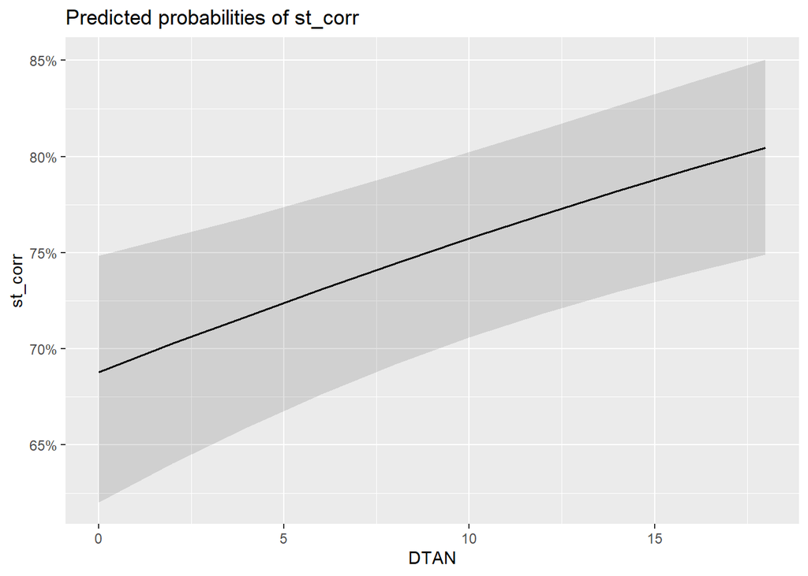

|  | st_corr |  |  |  | st_corr |  |  |  | st_corr |  |  |  |
| --- | --- | --- | --- | --- | --- | --- | --- | --- | --- | --- | --- | --- |
| Predictors | Log-Odds | std. Error | CI | p | Log-Odds | std. Error | CI | p | Log-Odds | std. Error | CI | p |
| (Intercept) | 0.84 | 0.14 | 0.56 – 1.11 | **<0.001** | 0.77 | 0.15 | 0.47 – 1.07 | **<0.001** | 0.79 | 0.15 | 0.49 – 1.09 | **<0.001** |
| DTF | 0.06 | 0.01 | 0.03 – 0.08 | **<0.001** |  |  |  |  |  |  |  |  |
| DTAF |  |  |  |  | 0.04 | 0.01 | 0.02 – 0.06 | **<0.001** |  |  |  |  |
| DTAN |  |  |  |  |  |  |  |  | 0.03 | 0.01 | 0.02 – 0.05 | **<0.001** |
| Random Effects |  |  |  |  |  |  |  |  |  |  |  |  |
| σ<sup>2</sup> | 3.29 |  |  |  | 3.29 |  |  |  | 3.29 |  |  |  |
| τ<sub>00</sub> | 0.26 <sub>workerId</sub> |  |  |  | 0.26 <sub>workerId</sub> |  |  |  | 0.26 <sub>workerId</sub> |  |  |  |
| ICC | 0.07 |  |  |  | 0.07 |  |  |  | 0.07 |  |  |  |
| N | 19 <sub>workerId</sub> |  |  |  | 19 <sub>workerId</sub> |  |  |  | 19 <sub>workerId</sub> |  |  |  |
| Observations | 1425 |  |  |  | 1425 |  |  |  | 1425 |  |  |  |
| Marginal R<sup>2</sup> / Conditional R<sup>2</sup> | 0.027 / 0.098 |  |  |  | 0.016 / 0.088 |  |  |  | 0.013 / 0.084 |  |  |  |
| AIC | 1596.260 |  |  |  | 1602.320 |  |  |  | 1605.442 |  |  |  |
| AICc | 1596.277 |  |  |  | 1602.337 |  |  |  | 1605.459 |  |  |  |

## Test phase

### Models #1 - without trial quality as random slope

Logistic mixed regression for the test phase. Does difference from prototypes or familiarity/novelty have an effect on correct categorization in the test phase?

```
## Generalized linear mixed model fit by maximum likelihood (Laplace
##   Approximation) [glmerMod]
##  Family: binomial  ( logit )
## Formula: rt_resp ~ DTF * tq + (1 | workerId)
##    Data: tdlmm
##
##      AIC      BIC   logLik deviance df.resid
##   1898.7   1925.4   -944.3   1888.7     1532
##
## Scaled residuals:
##     Min      1Q  Median      3Q     Max
## -1.6743 -0.8022 -0.3888  0.8119  4.3610
##
## Random effects:
##  Groups   Name        Variance Std.Dev.
##  workerId (Intercept) 0.5075   0.7124
## Number of obs: 1537, groups:  workerId, 19
##
## Fixed effects:
##             Estimate Std. Error z value Pr(>|z|)
## (Intercept)  0.55303    0.21691   2.550 0.010786 *
## DTF         -0.15091    0.01963  -7.686 1.52e-14 ***
## tqold       -0.39535    0.18922  -2.089 0.036672 *
## DTF:tqold    0.08650    0.02462   3.513 0.000443 ***
## ---
## Signif. codes:  0 '***' 0.001 '**' 0.01 '*' 0.05 '.' 0.1 ' ' 1
##
## Correlation of Fixed Effects:
##           (Intr) DTF    tqold
## DTF       -0.536
## tqold     -0.492  0.615
## DTF:tqold  0.428 -0.796 -0.805
```

[output not shown]

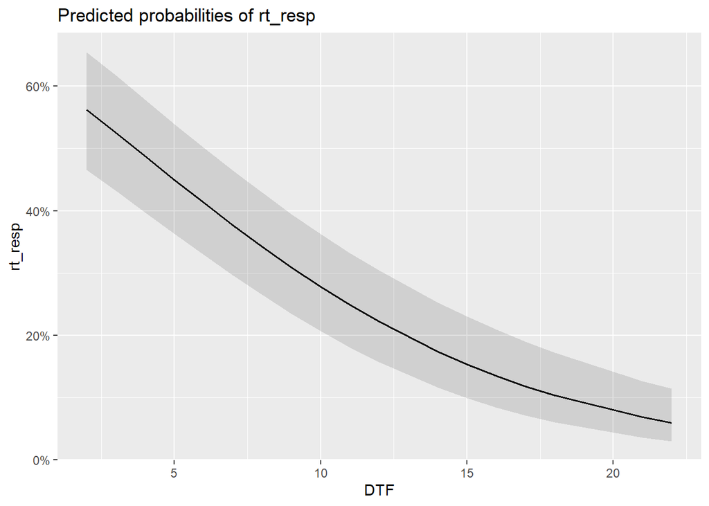

[output not shown]

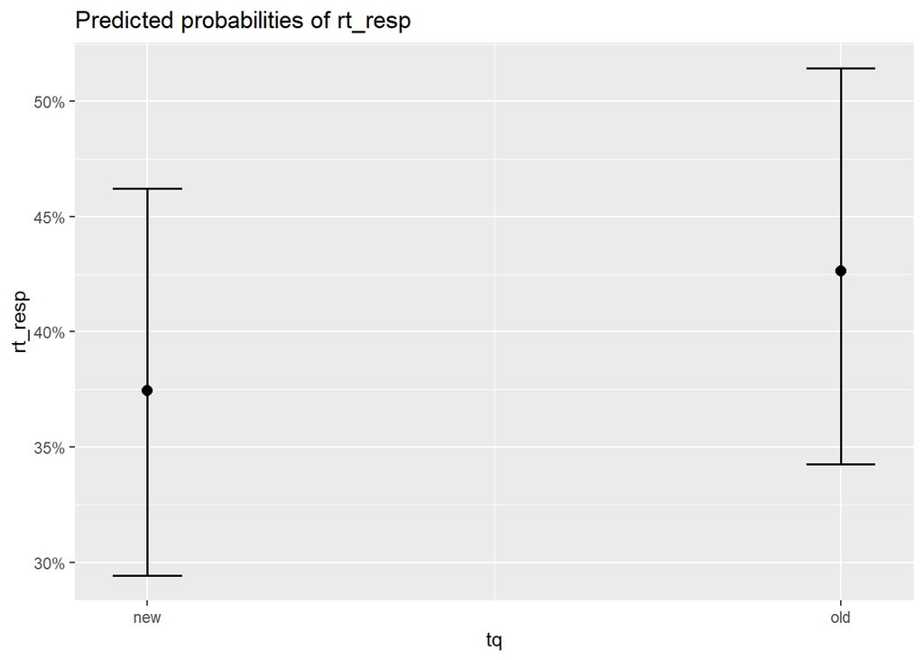

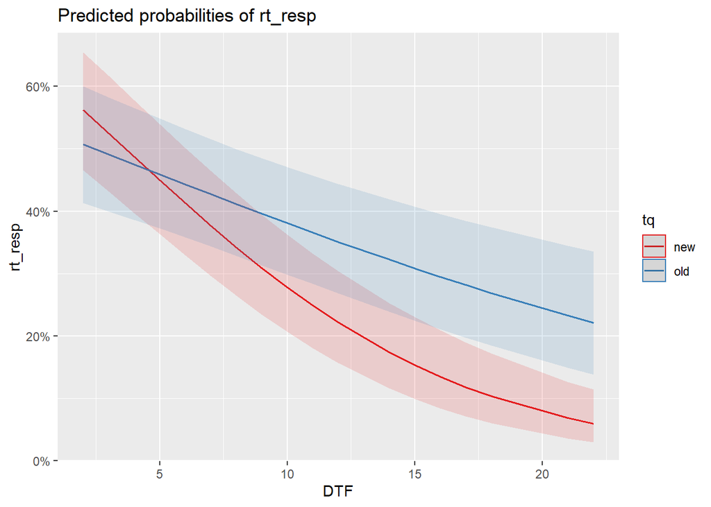

```
## Generalized linear mixed model fit by maximum likelihood (Laplace
##   Approximation) [glmerMod]
##  Family: binomial  ( logit )
## Formula: rt_resp ~ DTAF * tq + (1 | workerId)
##    Data: tdlmm
##
##      AIC      BIC   logLik deviance df.resid
##   1897.4   1924.1   -943.7   1887.4     1532
##
## Scaled residuals:
##     Min      1Q  Median      3Q     Max
## -1.6881 -0.7979 -0.3826  0.8343  4.8027
##
## Random effects:
##  Groups   Name        Variance Std.Dev.
##  workerId (Intercept) 0.5199   0.721
## Number of obs: 1537, groups:  workerId, 19
##
## Fixed effects:
##             Estimate Std. Error z value Pr(>|z|)
## (Intercept)  2.86573    0.45720   6.268 3.66e-10 ***
## DTAF        -0.25836    0.03354  -7.703 1.33e-14 ***
## tqold       -1.42512    0.55739  -2.557   0.0106 *
## DTAF:tqold   0.12469    0.04332   2.879   0.0040 **
## ---
## Signif. codes:  0 '***' 0.001 '**' 0.01 '*' 0.05 '.' 0.1 ' ' 1
##
## Correlation of Fixed Effects:
##            (Intr) DTAF   tqold
## DTAF       -0.915
## tqold      -0.711  0.749
## DTAF:tqold  0.706 -0.771 -0.980
```

[output not shown]

```
## Data were 'prettified'. Consider using `terms="DTAF [all]"` to get smooth plots.
```

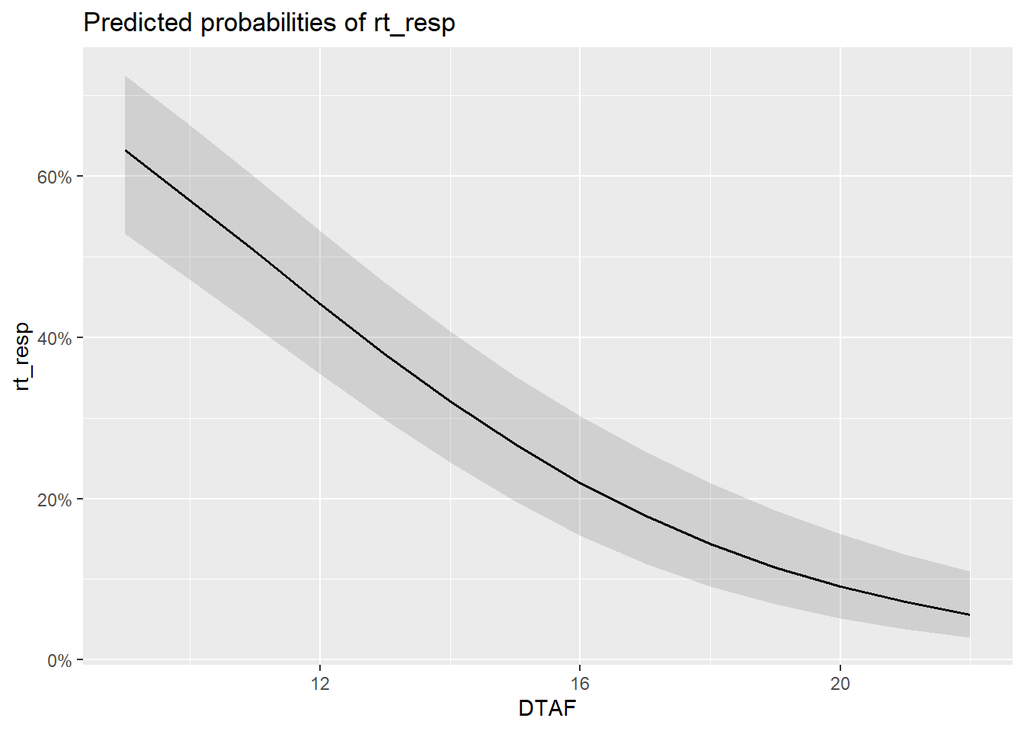

[output not shown]

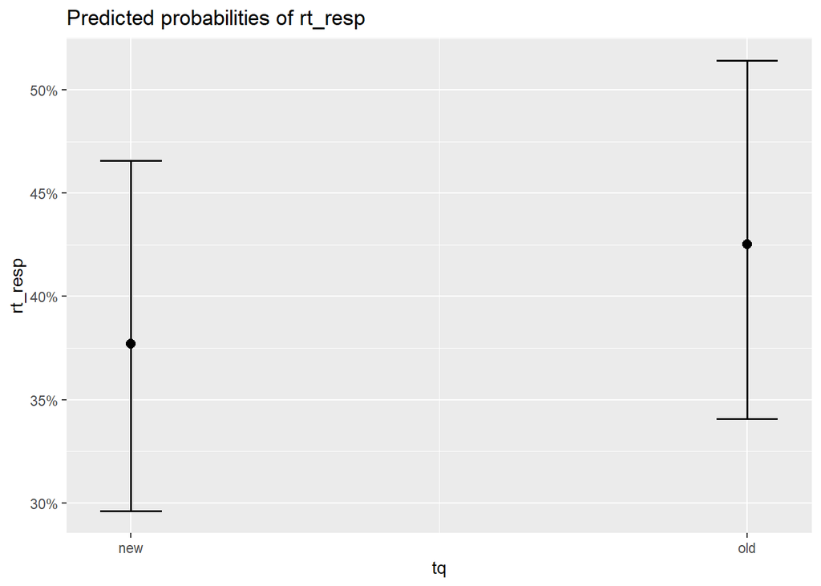

```
## Data were 'prettified'. Consider using `terms="DTAF [all]"` to get smooth plots.
```

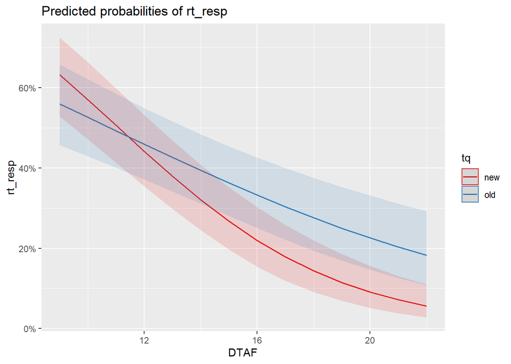

```
## Generalized linear mixed model fit by maximum likelihood (Laplace
##   Approximation) [glmerMod]
##  Family: binomial  ( logit )
## Formula: rt_resp ~ DTAN * tq + (1 | workerId)
##    Data: tdlmm
##
##      AIC      BIC   logLik deviance df.resid
##   1917.1   1943.8   -953.6   1907.1     1532
##
## Scaled residuals:
##     Min      1Q  Median      3Q     Max
## -1.8144 -0.7873 -0.4217  0.8750  3.7560
##
## Random effects:
##  Groups   Name        Variance Std.Dev.
##  workerId (Intercept) 0.5151   0.7177
## Number of obs: 1537, groups:  workerId, 19
##
## Fixed effects:
##             Estimate Std. Error z value Pr(>|z|)
## (Intercept)  3.69249    0.59622   6.193 5.90e-10 ***
## DTAN        -0.32528    0.04512  -7.209 5.62e-13 ***
## tqold       -1.60095    0.77694  -2.061   0.0393 *
## DTAN:tqold   0.13989    0.06071   2.304   0.0212 *
## ---
## Signif. codes:  0 '***' 0.001 '**' 0.01 '*' 0.05 '.' 0.1 ' ' 1
##
## Correlation of Fixed Effects:
##            (Intr) DTAN   tqold
## DTAN       -0.951
## tqold      -0.707  0.728
## DTAN:tqold  0.704 -0.740 -0.990
```

[output not shown]

```
## Data were 'prettified'. Consider using `terms="DTAN [all]"` to get smooth plots.
```

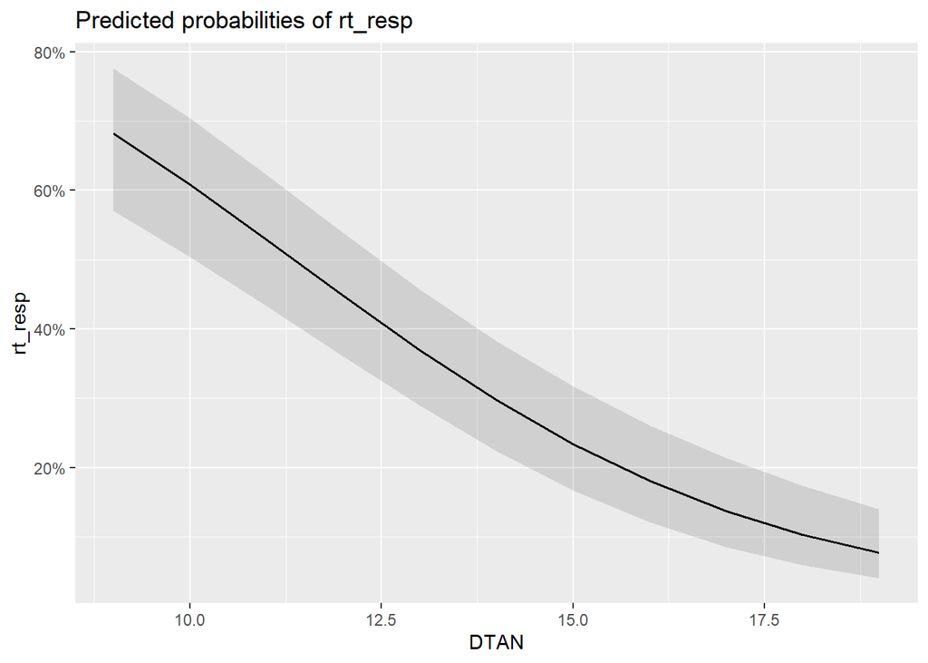

[output not shown]

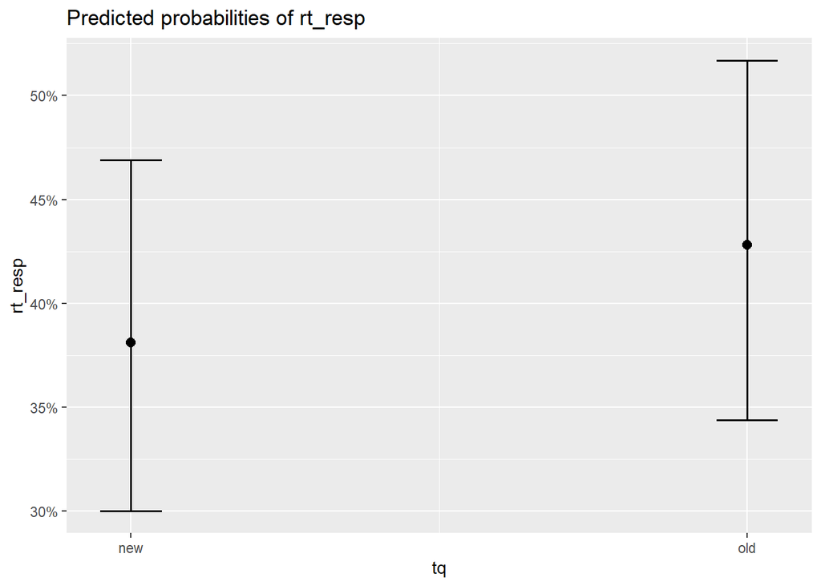

```
## Data were 'prettified'. Consider using `terms="DTAN [all]"` to get smooth plots.
```

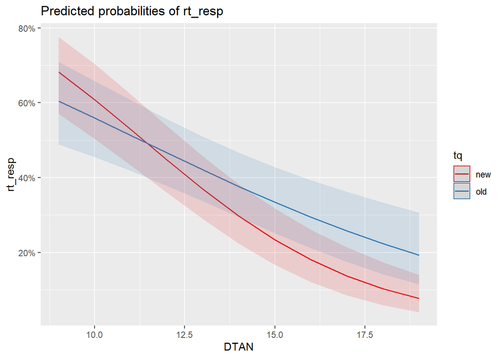

|  | rt_resp |  |  |  | rt_resp |  |  |  | rt_resp |  |  |  |
| --- | --- | --- | --- | --- | --- | --- | --- | --- | --- | --- | --- | --- |
| Predictors | Log-Odds | std. Error | CI | p | Log-Odds | std. Error | CI | p | Log-Odds | std. Error | CI | p |
| (Intercept) | 0.55 | 0.22 | 0.13 – 0.98 | **0.011** | 2.87 | 0.46 | 1.97 – 3.76 | **<0.001** | 3.69 | 0.60 | 2.52 – 4.86 | **<0.001** |
| DTF | -0.15 | 0.02 | -0.19 – -0.11 | **<0.001** |  |  |  |  |  |  |  |  |
| tq [old] | -0.40 | 0.19 | -0.77 – -0.02 | **0.037** | -1.43 | 0.56 | -2.52 – -0.33 | **0.011** | -1.60 | 0.78 | -3.12 – -0.08 | **0.039** |
| DTF * tq [old] | 0.09 | 0.02 | 0.04 – 0.13 | **<0.001** |  |  |  |  |  |  |  |  |
| DTAF |  |  |  |  | -0.26 | 0.03 | -0.32 – -0.19 | **<0.001** |  |  |  |  |
| DTAF * tq [old] |  |  |  |  | 0.12 | 0.04 | 0.04 – 0.21 | **0.004** |  |  |  |  |
| DTAN |  |  |  |  |  |  |  |  | -0.33 | 0.05 | -0.41 – -0.24 | **<0.001** |
| DTAN * tq [old] |  |  |  |  |  |  |  |  | 0.14 | 0.06 | 0.02 – 0.26 | **0.021** |
| Random Effects |  |  |  |  |  |  |  |  |  |  |  |  |
| σ<sup>2</sup> | 3.29 |  |  |  | 3.29 |  |  |  | 3.29 |  |  |  |
| τ<sub>00</sub> | 0.51 <sub>workerId</sub> |  |  |  | 0.52 <sub>workerId</sub> |  |  |  | 0.52 <sub>workerId</sub> |  |  |  |
| ICC | 0.13 |  |  |  | 0.14 |  |  |  | 0.14 |  |  |  |
| N | 19 <sub>workerId</sub> |  |  |  | 19 <sub>workerId</sub> |  |  |  | 19 <sub>workerId</sub> |  |  |  |
| Observations | 1537 |  |  |  | 1537 |  |  |  | 1537 |  |  |  |
| Marginal R<sup>2</sup> / Conditional R<sup>2</sup> | 0.097 / 0.218 |  |  |  | 0.093 / 0.216 |  |  |  | 0.068 / 0.194 |  |  |  |
| AIC | 1898.690 |  |  |  | 1897.434 |  |  |  | 1917.113 |  |  |  |
| AICc | 1898.729 |  |  |  | 1897.473 |  |  |  | 1917.152 |  |  |  |